# Bayesian Hierarchical Regression using Approximate Bayesian Computing in R

## *By Saurav Jadhav*

Consider you are working on a medical dataset that consists of patients' information who regularly visits the clinic.

Now for every patient, we will have multiple observations on several health parameters such as blood glucose level, blood pressure, and so on.

And we are interested in the relationship of these health parameters with **Forced vital capacity (FVC)**

FVC is the maximum amount of air a person can forcibly exhale from their lungs after fully inhaling.

A diminished FVC value is a sign of several conditions, including Chronic obstructive pulmonary disease (COPD), chronic bronchitis, emphysema, and bronchiectasis.

So it becomes vital to understand what relationship the other health parameters, such as blood pressure, share with the FVC.

When thinking about understanding the relationship between variables, the first thing that comes to mind is the regression setup.

If we consider building the simplest possible regression model, we will have the regression coefficients of different health parameters the same for all the patients. This model will not give us a complete picture of the health of individual patients. The above model is called a **pooled model**.

On the other hand, if we build a separate model for each patient, we will get the information about each and every patient separately. Here, we are considering every patient as some different entity. But that may not be true. Patients may share something in common. Assuming every patient is a completely different entity can lead to an inaccurate picture. Also, we may run across some other problems. We may not have sufficient data on some patients to build a regression model on which we are confident.

The above model is called an **unpooled model**.

Here we will be using **Partial pooling**. Specifically, we will assume regression coefficients are different for different patients as in the unpooled case, but the coefficients all share some common part. We can model this by assuming that each individual coefficient comes from a common group distribution.

## Bayesian Hierarchical Linear Regression

- Bayesian Hierarchical Linear Regression is a statistical model that allows for the analysis of data that have a hierarchical or nested structure.
- In this model, the data are assumed to come from multiple levels, with each level having its own set of predictors and outcomes. For example, in a our medical study, the patients may be nested within hospitals, and each patient has their own characteristics (e.g., age, sex, blood pressure) that influence their response to a FVC.
- The hierarchical structure allows for the estimation of both individual-level effects and group-level effects, which can improve the accuracy of the estimates and account for the variability within and between groups. The Bayesian approach allows for the incorporation of prior knowledge and uncertainty into the model, which can improve the interpretability of the results and provide more robust inferences.

### Theory for generating the data

For the illustration, we will be specifically working on the generated data.

For our data we will be assuming 5 levels or classes. If we use analogy from our FVC case, then levels can correspond to the patients.

**We genereate total 100 observations with 5 levels.**

Observations are equally distributed across all levels. Hence, we have 20 observations for each level.

$$\mu_{1i}\sim Cauchy(0,1)\ \forall i=1,2,3,4,5$$$$\mu_{1i}\ corresponds\ to\ the\ prior\ mean\ for\ X_1\ with\ i^{th}\ level$$

$$X_{1}^i\ \sim N(\mu_{1i},5) $$$$ X_{1}^i\ corresponds\ to\ observations\ of\ X_{1}\ with\ i^{th}\ level$$

Similarly,

$$\mu_{2i}\sim N(0,1)\ \forall i=1,2,3,4,5$$$$X_{2}^i\ \sim N(\mu_{2i},1) $$$$ X_{2}^i\ corresponds\ to\ observations\ of\ X_{2}\ with\ i^{th}\ level$$

Now, we can write:

$$\underline{y^i}= \beta_{0i}+\beta_{1i}\underline{X_{1}^i}+ \beta_{2i}\underline{X_{2}^i} $$

Where, $$\underline{y^i}\ is\ the\ reponse\ vector\ corresponds\ to\ the\ i^{th}\ level\ $$

### Below is the code to generate the data as per the above theory

```r
set.seed(1779)
n=100
level=5 # In the data there are 5 classes
k=n/level # no. of observations in each class
mu1= rcauchy(level)
mu2= rnorm(level)
sigma1= 5
sigma2= 1
X1=c()
X2=c()
count=0
for(i in 1:level)
    {
    X1[((count*20)+1):((count+1)*20)]=rnorm(20,mu1[i],sigma1)
    X2[((count*20)+1):((count+1)*20)]=rnorm(20,mu2[i],sigma2)
    count=count+1
    }
eps=rnorm(n)
mubeta0=rnorm(1,8,1)
mubeta1=rnorm(1,5,3)
mubeta2=rnorm(1,3,2)
print('Beta0 Values are:')
beta0= abs(rnorm(level,mubeta0)); beta0
print('Beta1 Values are:')
beta1= rcauchy(level,mubeta1) ;beta1
print('Beta2 Values are:')
beta2= rnorm(level,mubeta2,3);beta2
X1beta=c()
X2beta=c()
count=0
for(i in 1:level)
    {
    X1beta[((count*20)+1):((count+1)*20)]= beta0[i]+(beta1[i]*X1[((count*20)+1):((count+1)*20)])
    X2beta[((count*20)+1):((count+1)*20)]= beta2[i]*X2[((count*20)+1):((count+1)*20)]
    count=count+1
    }

y=X1beta+X2beta
data=cbind(y,X1,X2)
```

```
[1] "Beta0 Values are:"
```

1. 8.07896197601236

2. 9.24124817084238

3. 8.80408695438716

4. 8.56418792331896

5. 9.01890520903835

```
[1] "Beta1 Values are:"
```

1. 11.6414734704793

2. 6.90211389358368

3. 8.44457562698447

4. 9.46837589696629

5. 8.62435416153365

```
[1] "Beta2 Values are:"
```

1. 3.42089472242935

2. 5.68552443618085

3. 2.89594423315203

4. 5.65609898299507

5. 2.25798144669538

### Plotting the data

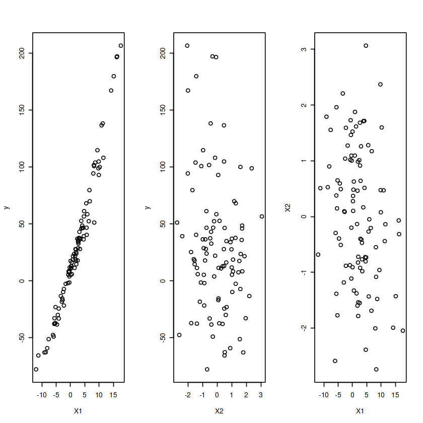

```r
# we plot the data
par(mfrow=c(1,3))
plot(X1,y)
plot(X2,y)
plot(X1,X2)
```

$$We\ observe\ no\ relationship\ between\ X_2\ and\ y$$

### We use No-pooling to generate relevant priors for the beta's

1 . We fit separate regression line to each level in order to obtain:

$$ \\ \hat{\beta_{0i}},\ \hat{\beta_{1i}},\ \hat{\beta_{2i}}\ \forall i=1,2,3,4,5\\ $$

2 . We use mean of these no-pooling coefficients as a prior to obtain the sample of regression coefficients. $$ A. \ \hat{\mu_{\beta_{0}}}= \frac{1}{5} \sum_{i=1}^5 \hat{\beta_{0i}} \\ B. \ \mu_{\beta_{0}} \sim N(\hat{\mu_{\beta_{0}}},900) \\ C. \ \beta_{0i} \sim N(\mu_{\beta_{0}},\sigma_{\beta_{0}}^2) \\ similar\ to\ above,\ \hat{\sigma_{\beta_{0}}}\ is\ obtained\ from\ \hat{\beta_{0i}}\ using\ all\ i's\ \\ $$ $$\\ \\ We\ do\ the\ above\ process\ for\ \beta_{1i},\ \beta_{2i}\ \forall\ i\ and\ obtain\ the\ values\ of\ \\ \hat{\mu_{\beta_{1}}}, \hat{\sigma_{\beta_{1}}}, \hat{\mu_{\beta_{1}}}, and\ \hat{\sigma_{\beta_{2}}} $$

3 . The posterior regression coefficients are obtained using Approximate Bayesian Computing (ABC)

### Code for the above workflow

```r
# we fit separate regression line for every level separately
#for( i in 1:level)
mod=list()
count=0
for( i in 1:level)
    {
mod[[i]]=lm(y[((count*k)+1):((count+1)*k)]~(X1[((count*k)+1):((count+1)*k)]+X2[((count*k)+1):((count+1)*k)]))
count=count+1
    }
```

```r
# collecting all the coefficients (for different classes)
beta1_hat=c()
beta0_hat=c()
beta2_hat=c()
for(i in 1:level)
{
    beta0_hat[i]= mod[[i]]$coefficients[1]
    beta1_hat[i]= mod[[i]]$coefficients[2]
    beta2_hat[i]= mod[[i]]$coefficients[3]
}
```

```r
# Now we use the above coefficients in the form of priors for the bayesian hierarchical modelling
m_beta0= mean(beta0_hat)
m_beta1=mean(beta1_hat)
m_beta2= mean(beta2_hat)
sd_beta0=sd(beta0_hat)
sd_beta1=sd(beta1_hat)
sd_beta2=sd(beta2_hat)
```

[figure not shown]

### Approximate Bayesian Computing (ABC) to obtain posterior sample

Approximate Bayesian Computation (ABC) is a statistical method that allows for the inference of complex models when likelihood functions are difficult or impossible to calculate. ABC works by simulating data from a model using a set of parameters sampled from a prior distribution. These simulated data are then compared to the actual observed data, and the parameters that produce simulations that are most similar to the observed data are retained. This process is repeated many times to generate a posterior distribution of the parameters that are consistent with the observed data.

#### Steps to compute posterior samples of regression coefficients using ABC:

$$1.\ From\ the\ above\ work flow,\ we\ obtain\ 10^7\ samples\ of\ \beta_{0i}\ \beta_{1i},\ \beta_{2i}\\ $$

$$2. \ Now \ we\ compute\ the\ euclidean\ distance\ of\ every\ sample\ obtained\ of\\ \ \ \ \ \ \ \ \ \ \ \ \ the\ regression\ coefficients\ from\ that\ of\ obtained\ by\ No-pooling\ method\\ $$

$$3. \ We\ select\ that\ sample\ as\ our\ posterior\ sample\ for\ which\ the\ distance\ is\ less\ than\ some\ threshold. \ (In\ our\ case\ the\ threshold\ is\ one.)\\ $$

$$ \ 4. \ The\ complete\ flow\ is\ represented\ below\ $$

[figure not shown]

### $$In\ the\ above\ flow\ diagram,\ \beta_{ki}^j\ indicate\ the\ j^{th}\ sample\ of\ the\ regression\ coefficient\ for\ the\ i^{th}\ level\ for\ the\ k^{th}\ variable\ $$

### Code to find the posterior sample using the ABC method as per the above flow

```r
# Now we use some prior for our betas
# Assuming we do not have much of an idea about the parameters
# we will select some vague priors
#y_bar=mean(y)
sim=10^7
beta2_gen=beta1_gen=beta0_gen=matrix(0,nrow=level,ncol=sim) # just initializing the list
thresh=1
#y_gen=matrix(0,nrow=n,ncol=sim)
#sigma=c()
diff_b2=diff_b1=diff_b0=c()
for( i in 1:sim)
    {
        mubeta0= rnorm(1,m_beta0,30)
        sigmabeta0= abs(rnorm(1,sd_beta0,10))
        mubeta1= rnorm(1,m_beta1,10)
        sigmabeta1= abs(rnorm(1,sd_beta1,10))
        mubeta2= rnorm(1,m_beta2,30)
        sigmabeta2= abs(rnorm(1,sd_beta2,30))
        #count=0
        #sigma[i]= abs(rnorm(1,0,10))
    for(j in 1:level)
            {
        b0=beta0_gen[j,i]= rnorm(1,mubeta0,sigmabeta0)
        b1=beta1_gen[j,i]= rnorm(1,mubeta1,sigmabeta1)
        b2=beta2_gen[j,i]= rnorm(1,mubeta2,sigmabeta2)
        }
        diff_b0[i]= abs(sqrt(sum((beta0_gen[,i]-beta0_hat)^2)))
        diff_b1[i]= abs(sqrt(sum((beta1_gen[,i]-beta1_hat)^2)))
        diff_b2[i]= abs(sqrt(sum((beta2_gen[,i]-beta2_hat)^2)))

}
index_b0=which(diff_b0<thresh)
index_b1= which(diff_b1<thresh)
index_b2= which(diff_b2<thresh)

m_beta0=apply(beta0_gen[,index_b0],1,mean)
m_beta1= apply(beta1_gen[,index_b1],1,mean)
m_beta2= apply(beta1_gen[,index_b2],1,mean)
print("Number of posterior samples obtained for Beta0 are: ");length(index_b0)
print("Number of posterior samples obtained for Beta1 are: ");length(index_b1)
print("Number of posterior samples obtained for Beta2 are: ");length(index_b2)
```

```
[1] "Number of posterior samples obtained for Beta0 are: "
```

1912

```
[1] "Number of posterior samples obtained for Beta1 are: "
```

56

```
[1] "Number of posterior samples obtained for Beta2 are: "
```

5

#### From above we can see that very few samples have been accepted as the posterior sample. Especially for:

#### $$\underline{\beta_{1}}, and\ \underline{\beta_{2}} \\ Here, \underline{\beta_{1}}\ is\ a\ vector\ of\ \beta_{1i}\ where\ i\ is\ the\ level\ \\ Corresponding\ interpretations\ can\ be\ drawn\ for\ \underline{\beta_{2}}\ and\ \underline{\beta_{0}} $$

#### Comparing average of the posterior sample to that of the original coefficients

```r
m_beta0 # mean of the posterior sample of Beta0
beta0 # Original Coefficients of Beta0
m_beta1
beta1
m_beta2
beta2
# mean of posterior samples based on the threshold  are close to the orginal values of beta's
# Except for that of beta2
```

1. 8.50266125532234

2. 8.92739176270345

3. 8.75213201606846

4. 8.66968242544609

5. 8.8493839302067

1. 8.07896197601236

2. 9.24124817084238

3. 8.80408695438716

4. 8.56418792331896

5. 9.01890520903835

1. 11.5131651764437

2. 6.98130966649172

3. 8.48790842587322

4. 9.48495143370852

5. 8.61771583516374

1. 11.6414734704793

2. 6.90211389358368

3. 8.44457562698447

4. 9.46837589696629

5. 8.62435416153365

1. 15.2144513314431

2. 12.8985845459961

3. 26.1035282772063

4. 13.6876354023017

5. 1.90144746592252

1. 3.42089472242935

2. 5.68552443618085

3. 2.89594423315203

4. 5.65609898299507

5. 2.25798144669538

#### $$ From\ the\ above\ comparison\ we\ can\ see\ that\ mean\ of\ the\ posterior\ sample\ for\ \underline{\beta_{0}},\ and\ \underline{\beta_{1}}\ are\ close\ to\ the\ true\ value.\ We\ will\ visually\ see\ the\ fit.\ $$

#### Plots for the posterior samples

```r
# Converting the posterior samples for 5 levels (matrix) into the vector form
gen_beta0=as.vector(beta0_gen[,index_b0])
gen_beta1=as.vector(beta1_gen[,index_b1])
gen_beta2=as.vector(beta2_gen[,index_b2])
beta0.samples=t(beta0_gen[,index_b0])
beta1.samples= t(beta1_gen[,index_b1])
beta2.samples= t(beta2_gen[,index_b1])
```

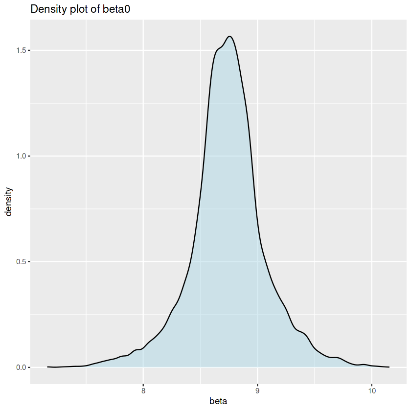

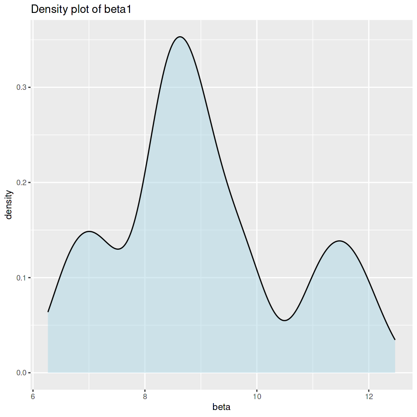

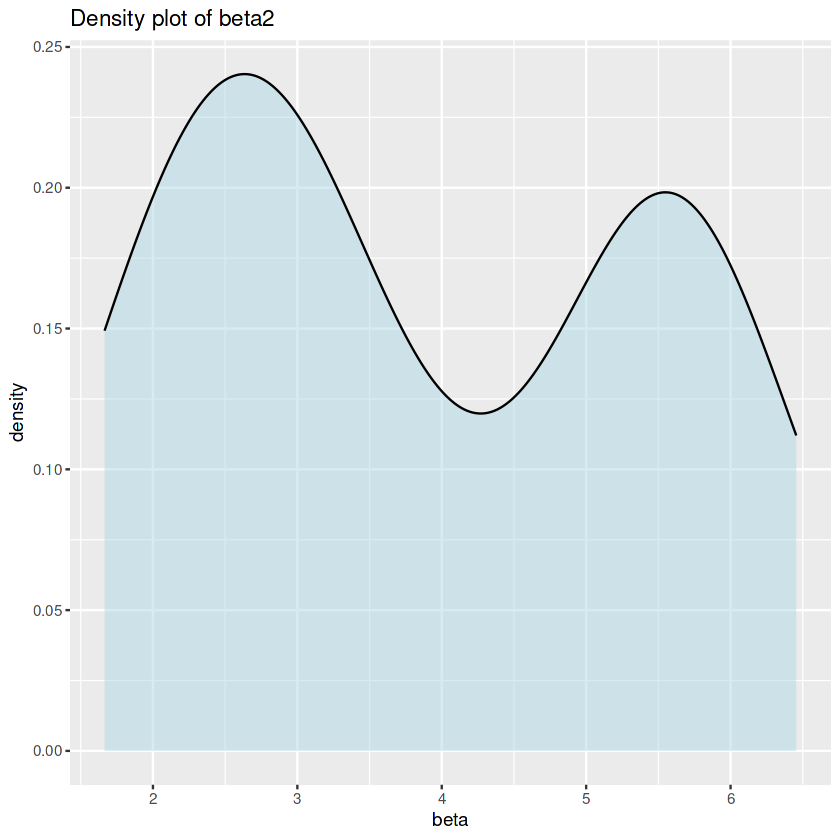

```r
library(ggplot2)
# Density plots
par(mfrow=c(3,1))
  ggplot(data.frame(beta = gen_beta0), aes(x = beta)) +
  geom_density(fill = "lightblue", alpha = 0.5) +
  labs(title = paste0("Density plot of beta0"))

  ggplot(data.frame(beta = gen_beta1), aes(x = beta)) +
  geom_density(fill = "lightblue", alpha = 0.5) +
  labs(title = paste0("Density plot of beta1"))


  ggplot(data.frame(beta = gen_beta2), aes(x = beta)) +
  geom_density(fill = "lightblue", alpha = 0.5) +
  labs(title = paste0("Density plot of beta2"))
```

### $$From\ above\ we\ can\ see\ that\ the\ density\ plot\ for\ \beta_{0}\ looks\ more\ stable\ and\ closer\ to\ the\ original\ distribution\ $$

#### Box Plots for posterior samples of:

#### $$\beta_{0i},\ \beta_{1i},\ and\ \beta_{2i}\ for\ all\ levels\ i $$

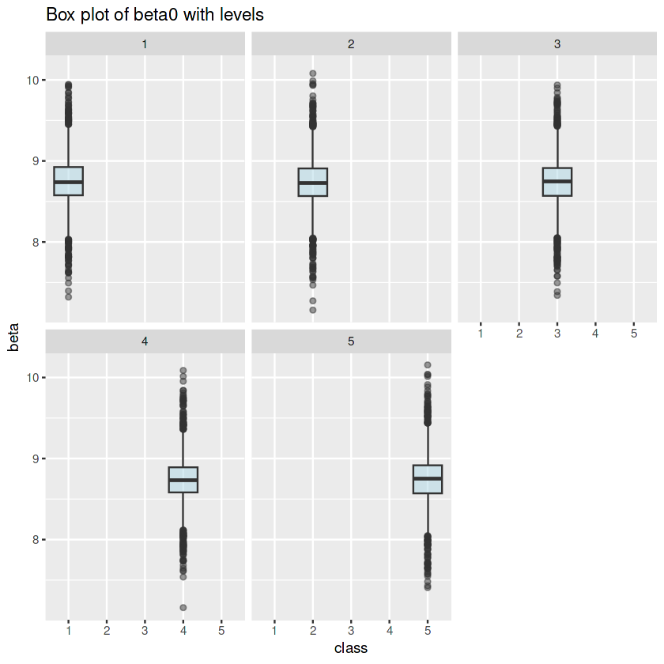

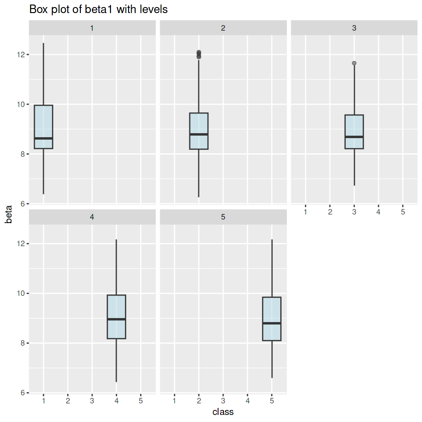

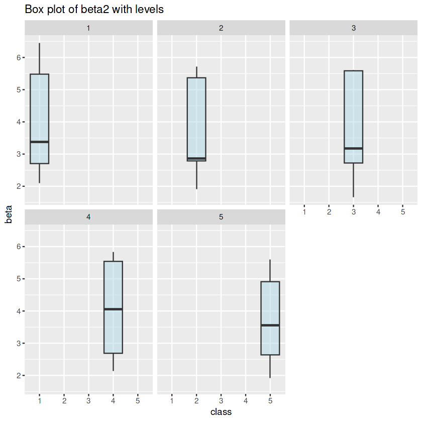

```r
# Box plots


  ggplot(data.frame(beta = gen_beta0, class = factor(rep(1:5, each = length(gen_beta0)/level))),
         aes(y = beta, x = class)) +
  geom_boxplot(fill = "lightblue", alpha = 0.5) +
  facet_wrap(~ class) +
  labs(title = paste0("Box plot of beta0 with levels"))

  ggplot(data.frame(beta = gen_beta1, class = factor(rep(1:5, each = length(gen_beta1)/level))),
         aes(y = beta, x = class)) +
  geom_boxplot(fill = "lightblue", alpha = 0.5) +
  facet_wrap(~ class) +
  labs(title = paste0("Box plot of beta1 with levels"))

    ggplot(data.frame(beta = gen_beta2, class = factor(rep(1:5, each = length(gen_beta2)/level))),
         aes(y = beta, x = class)) +
  geom_boxplot(fill = "lightblue", alpha = 0.5) +
  facet_wrap(~ class) +
  labs(title = paste0("Box plot of beta2 with levels"))
```

#### Trace Plots

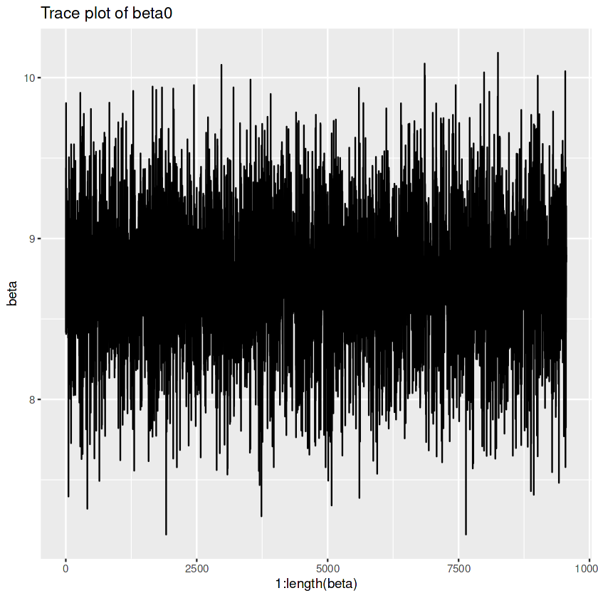

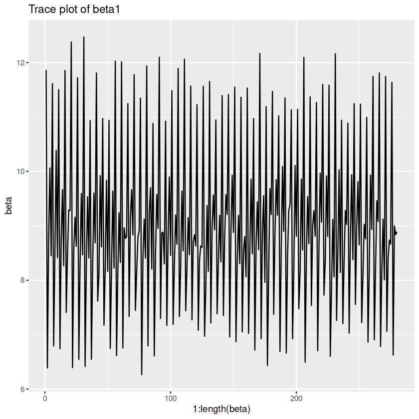

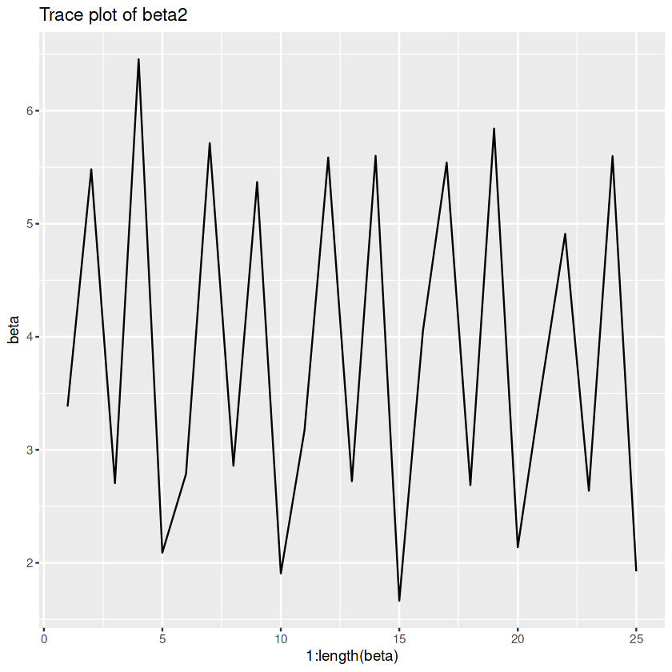

```r
# Trace plots

  ggplot(data.frame(beta = gen_beta0), aes(x = 1:length(beta))) +
  geom_line(aes(y = beta)) +
  labs(title = paste0("Trace plot of beta0"))

  ggplot(data.frame(beta = gen_beta1), aes(x = 1:length(beta))) +
  geom_line(aes(y = beta)) +
  labs(title = paste0("Trace plot of beta1"))

  ggplot(data.frame(beta = gen_beta2), aes(x = 1:length(beta))) +
  geom_line(aes(y = beta)) +
  labs(title = paste0("Trace plot of beta2"))
```

#### We obtain 95% credible plot for the regression setup using the posterior Beta samples.

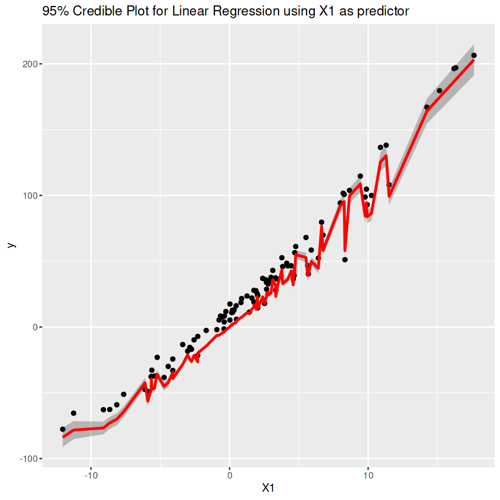

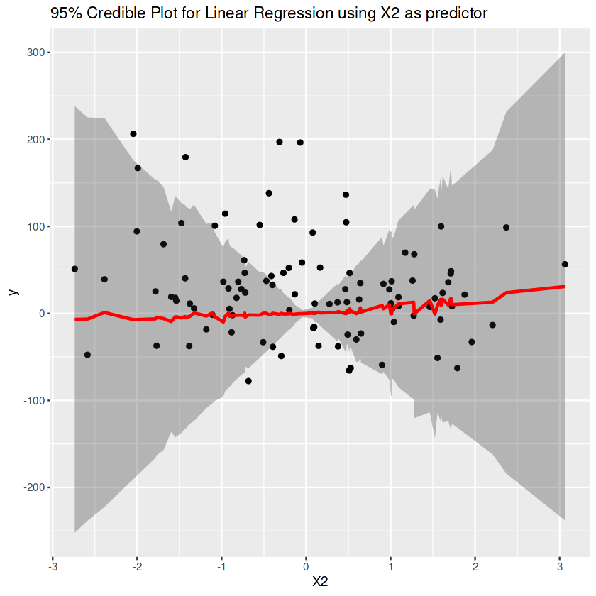

```r
# Generate predicted values for the range of predictor values
y.predict = matrix(0,nrow=n,ncol= dim(beta1.samples)[1])

for( i in 1:(dim(beta1.samples)[1]))
    {
    count=0

    for( j in 1:level)
        {

y.predict[((count*20)+1):((count+1)*20),i]=beta1.samples[i,j]*X1[((count*20)+1):((count+1)*20)]
        count=count+1
}

}

MAD= function(val)
    {
    mad=mean(abs(val-median(val)))
    return(mad)
}
# Compute the mean and standard deviation of the predicted values for each x value

y.median = apply(y.predict, 1, median)
y.mad= apply(y.predict, 1, MAD)
#y.sd = apply(y.predict, 1, sd)

# Compute the 95% credible interval for each x value
ci.lower = y.median - 1.96*y.mad
ci.upper = y.median + 1.96*y.mad

# Create a plot of the regression line with shaded confidence intervals
ggplot(data.frame(x = X1, y = y), aes(x = x, y = y)) +
  geom_point() +
  geom_ribbon(aes(ymin = ci.lower, ymax = ci.upper), alpha = 0.3) +
  geom_line(aes(x = X1, y = y.median), color = "red", linewidth = 1) +
  labs(title = "95% Credible Plot for Linear Regression using X1 as predictor",
       x = "X1", y = "y")


# Generate predicted values for the range of predictor values
y.predict = matrix(0,nrow=n,ncol= dim(beta2.samples)[1])

for( i in 1:(dim(beta2.samples)[1]))
    {
    count=0

    for( j in 1:level)
        {

y.predict[((count*20)+1):((count+1)*20),i]=beta2.samples[i,j]*X2[((count*20)+1):((count+1)*20)]
        count=count+1
}

}

# Compute the mean and standard deviation of the predicted values for each x value
y.mean = apply(y.predict, 1, mean)
y.sd = apply(y.predict, 1, sd)

# Compute the 95% credible interval for each x value
ci.lower = y.mean - 1.96*y.sd
ci.upper = y.mean + 1.96*y.sd

# Create a plot of the regression line with shaded confidence intervals
ggplot(data.frame(x = X2, y = y), aes(x = x, y = y)) +
  geom_point() +
  geom_ribbon(aes(ymin = ci.lower, ymax = ci.upper), alpha = 0.3) +
  geom_line(aes(x = X2, y = y.mean), color = "red", linewidth = 1) +
  labs(title = "95% Credible Plot for Linear Regression using X2 as predictor",
       x = "X2", y = "y")
```

- From the above 95% credible plots we can see that the Regression line generated from Bayesian Hierarchical model for variable X1 is sufficiently able to capture the pattern.
- Since, we already examined visually that no clear relationship exists between X2 and y. The 95% credible plot is for X2 is comes with a very wide 95% credible interval.

### What's Next?

- If you have carefully observed, the number of posterior samples that got accepted are different for different Beta's, which makes it difficult to draw inferences between the variables. Hence,this is one of the problem with using ABC.
- Very few posterior samples for beta got accepted even after generating 1e+7 samples.
- The above two problems can be approached by using different thresholds for different  
  Beta's, and changing the prior parameters of these *Beta* Coefficients.
- Of course, the code can be made simpler.

  **Will leave all this to the reader to explore.**

### Acknowledgement

##### Akanksha ma'am and Madhuri ma'am of the Department of Statistics, SPPU for introducing the concepts.

### References

1. [Bayesian_Hierarchical_Linear_Regression, by Carlos Souza](https://num.pyro.ai/en/stable/tutorials/bayesian_hierarchical_linear_regression.html)
2. [Forced vital capacity (FVC)](https://www.lung.org/lung-health-diseases/how-lungs-work/lung-capacity-and-aging)
3. [What Does a Low FVC Mean?](https://www.verywellhealth.com/forced-expiratory-capacity-measurement-914900#:~:text=Forced%20vital%20capacity%20can%20be,such%20as%20idiopathic%20pulmonary%20fibrosis)